# Group Project: Final Report

STAT5003

Group 38

Members:

- Quynh Giang Le - 530190754
- Kairui Huang - 530261917
- Rundong Shen - 530023418
- Haoyu Fang - 540576287
- Wanxin Bao - 540320288

```r
suppressPackageStartupMessages(library('tidyverse'))
suppressPackageStartupMessages(library('readr'))
suppressPackageStartupMessages(library('dplyr'))
suppressPackageStartupMessages(library('ggplot2'))
suppressPackageStartupMessages(library('broom'))
suppressPackageStartupMessages(library('tinytex'))
suppressPackageStartupMessages(library('caret'))
suppressPackageStartupMessages(library('gridExtra'))
suppressPackageStartupMessages(library(reshape2))
suppressPackageStartupMessages(library(randomForest))
suppressPackageStartupMessages(library(pROC))
suppressPackageStartupMessages(library(e1071))
suppressPackageStartupMessages(library(ranger))
library(parallel)
```

```r
data <- as.data.frame(read.csv("credit_train.csv", header = TRUE))
```

This dataset is from  
Rohan Paris. (2022). Credit score classification [dataset]. Kaggle. https://www.kaggle.com/datasets/parisrohan/credit-score-classification

# 1 Problem Overview

The goal of this work is to build a credit rating classification model using the amount of loans, the number of late payments, and other data currently available from banks. Users are categorised into pre-established credit risk categories based on the personal data they provide. This is a classification issue that involves supervised learning. The training data has a discrete label, Credit Score, that is known.  
This is an engaging activity with real-world application. Many banks and other financial institutions utilise credit scoring. It can successfully increase classification efficiency and lower labour costs by building a credit scoring classification model. This methodology is especially useful for handling massive volumes of lending data. Simultaneously, the methodology enhances classification standardisation, guaranteeing the impartiality and correctness of credit ratings, hence bolstering consumer acceptance of credit ratings. Technically speaking, there are numerous obstacles to overcome in order to create an accurate and efficient scoring model, such as feature selection, data cleaning, model optimisation, and more. This assignment can assist beginners in learning the fundamentals of data science, comprehending the benefits and drawbacks of various models, and investigating methods for enhancing model performance. This research procedure is intriguing and challenging at the same time.

# 2 Data Description

#### Description

The dataset contains 100000 samples and 28 feature columns including 16 numerical columns data and 12 categorical columns. Among them, it should be noted that due to data entry or issues with outliers, some numerical information is saved in char format and needs to be cleaned and formatted. The column names and data types are shown in the following figure:

```r
str(data)
```

```
## 'data.frame':    100000 obs. of  28 variables:
##  $ ID                      : num  5634 5635 5636 5637 5638 ...
##  $ Customer_ID             : chr  "CUS_0xd40" "CUS_0xd40" "CUS_0xd40" "CUS_0xd40" ...
##  $ Month                   : chr  "January" "February" "March" "April" ...
##  $ Name                    : chr  "Aaron Maashoh" "Aaron Maashoh" "Aaron Maashoh" "Aaron Maashoh" ...
##  $ Age                     : chr  "23" "23" "-500" "23" ...
##  $ SSN                     : chr  "821-00-0265" "821-00-0265" "821-00-0265" "821-00-0265" ...
##  $ Occupation              : chr  "Scientist" "Scientist" "Scientist" "Scientist" ...
##  $ Annual_Income           : chr  "19114.12" "19114.12" "19114.12" "19114.12" ...
##  $ Monthly_Inhand_Salary   : num  1825 NA NA NA 1825 ...
##  $ Num_Bank_Accounts       : int  3 3 3 3 3 3 3 3 2 2 ...
##  $ Num_Credit_Card         : int  4 4 4 4 4 4 4 4 4 4 ...
##  $ Interest_Rate           : int  3 3 3 3 3 3 3 3 6 6 ...
##  $ Num_of_Loan             : chr  "4" "4" "4" "4" ...
##  $ Type_of_Loan            : chr  "Auto Loan, Credit-Builder Loan, Personal Loan, and Home Equity Loan" "Auto Loan, Credit-Builder Loan, Personal Loan, and Home Equity Loan" "Auto Loan, Credit-Builder Loan, Personal Loan, and Home Equity Loan" "Auto Loan, Credit-Builder Loan, Personal Loan, and H…
##  $ Delay_from_due_date     : int  3 -1 3 5 6 8 3 3 3 7 ...
##  $ Num_of_Delayed_Payment  : chr  "7" "" "7" "4" ...
##  $ Changed_Credit_Limit    : chr  "11.27" "11.27" "_" "6.27" ...
##  $ Num_Credit_Inquiries    : num  4 4 4 4 4 4 4 4 2 2 ...
##  $ Credit_Mix              : chr  "_" "Good" "Good" "Good" ...
##  $ Outstanding_Debt        : chr  "809.98" "809.98" "809.98" "809.98" ...
##  $ Credit_Utilization_Ratio: num  26.8 31.9 28.6 31.4 24.8 ...
##  $ Credit_History_Age      : chr  "22 Years and 1 Months" NA "22 Years and 3 Months" "22 Years and 4 Months" ...
##  $ Payment_of_Min_Amount   : chr  "No" "No" "No" "No" ...
##  $ Total_EMI_per_month     : num  49.6 49.6 49.6 49.6 49.6 ...
##  $ Amount_invested_monthly : chr  "80.41529543900253" "118.28022162236736" "81.699521264648" "199.4580743910713" ...
##  $ Payment_Behaviour       : chr  "High_spent_Small_value_payments" "Low_spent_Large_value_payments" "Low_spent_Medium_value_payments" "Low_spent_Small_value_payments" ...
##  $ Monthly_Balance         : chr  "312.49408867943663" "284.62916249607184" "331.2098628537912" "223.45130972736786" ...
##  $ Credit_Score            : chr  "Good" "Good" "Good" "Good" ...
```

#### Possible Challenges

The dataset used for the project has 100,000 samples, many of which have missing values that must be filled by using different methods. It will be difficult to fill in a significant number of missing data. In the course of research, it is important to manage a variety of erroneous values, which is not limited to underlining, values that manifestly deviate from the usual range, etc. Numerous tasks, including data cleaning and data type translation, will be required for this. In the meanwhile, the model must resolve the difficult multi-class classification problem.

# 3 Initial Data Analysis

#### Data Cleaning

First, we would inspect the distribution of variables.

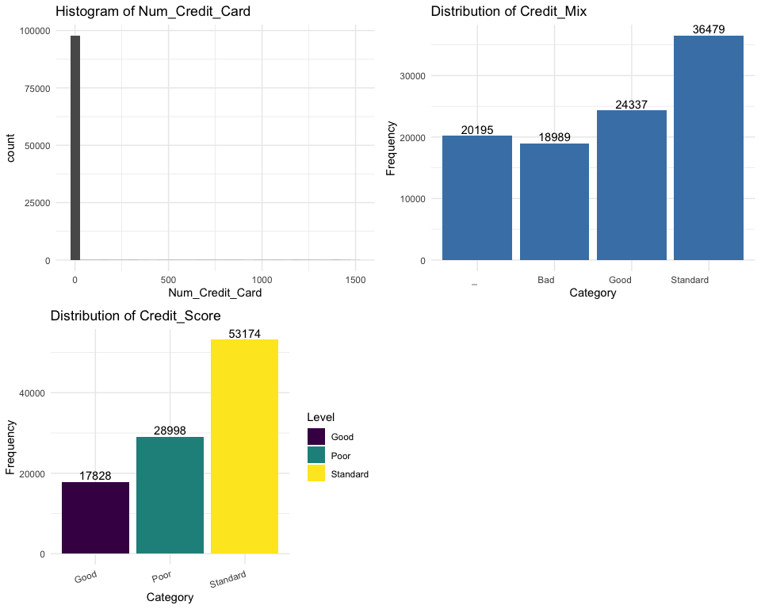

**Interpretation:**  
We can see that because of outliers, the distribution of numerical columns become very skewed, which is not normal. This is the same problem for the other numerical columns. This is because when investigating the % of missing values of numerical columns, the % of missing values is quite small (less than 10%) and just for a few columns. Therefore, it suggests that the reason of this skewness is outliers.  
For categorical column, there are some invalid values such as “_” above. After investigating the distribution of this invalid values, we could see that these values are random and possibly are error during data collection process such as error code from backend of an application.  
For target variable, it shows that there are 3 classes in total: Good, Poor, and Standard. There is no missing/invalid values in this column.

Next, we performed some checking functions to check for null/NaN values in every columns. Also, we performed functions to check if aside from outliers and invalid values, the values of those columns are unique by each customer, i.e. each customer only has 1 value for a column. Based on results, there are some columns have unique value by each customer such as Interest_Rate, Occupation, Credit_Mix, Num_of_Loan, etc., whereas some columns don’t have such as Age, Payment_Behavior, Num_Credit_Inquiries, etc.  
Therefore, we decided to perform these cleaning methods based on each problem:

| Type | Problem | Cleaning Methods |
| --- | --- | --- |
| Numerical | Unique value by customer | Detect outliers and replace with mode of each group of customer |
|  | Non-unique value by customer | Detect outliers and replace with data from nearest neighbor |
|  | Other columns | Detect outliers and data behavior to perform cleaning methods such as replace with mean of customer group, etc. |
| Categorical | Invalid values | Replace with mode of each group of customer |
|  | Null values | Because null values are acceptable so replace them with ‘Not specified’ value. |

```r
data <- read.csv("data_after_clean.csv", header = TRUE)
data <- data %>% select(-X)
```

#### EDA

We performed PCA plot to investigate decision boundary for model choices

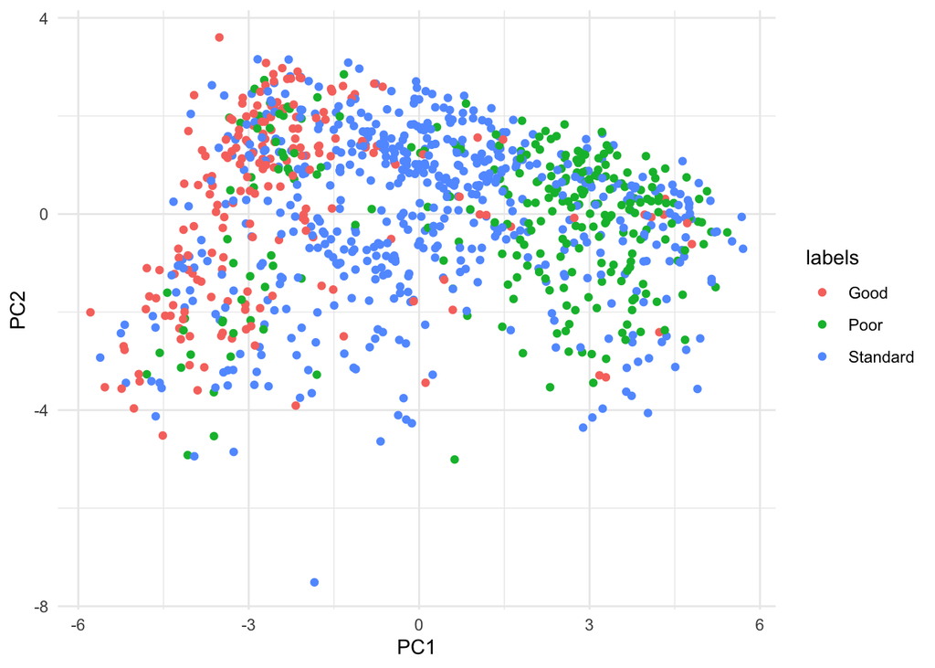

```r
pca.data <- data %>% sample_n(1000)
data.att <- select(pca.data, -'Credit_Score')
data.att <- model.matrix(~ . - 1, data = data.att)
credit_score <- factor(pca.data[["Credit_Score"]])
pca.scaled <- prcomp(data.att, scale = TRUE)
credit_score.df <- data.frame(PC1 = pca.scaled$x[, 1], PC2 = pca.scaled$x[, 2], PC3 = pca.scaled$x[, 3], labels = credit_score)
pca.plot <- ggplot(credit_score.df, aes(PC1, PC2, col = labels)) + geom_point() + theme_minimal()
print(pca.plot)
```

**Conclusion:**  
- The decision boundary is non-linear.  
- With class “Poor” and “Standard”, the data points are not tight together within 1 group, whereas data points in class “Good” are closer together.

# 4 Feature Engineering

#### Categorical Encoding

We use label encoding to encode the textual categorical data into numerical value. This is the data requirement of the model functions.

```r
set.seed(5003)
categorical_var <- c("Month","Occupation", "Credit_Mix", "Payment_of_Min_Amount", "Payment_Behaviour")
data[categorical_var] <- lapply(data[categorical_var], as.factor)
data[categorical_var] <- lapply(data[categorical_var], as.numeric)
```

#### Feature Selection

```r
set.seed(5003)
data$Credit_Score <- as.factor(data$Credit_Score)
importance_model <- randomForest(Credit_Score ~ ., data = data, ntree = 500, type = "classification")
```

```r
set.seed(5003)
importance <- randomForest::importance(importance_model)

importance_df <- data.frame(Feature = rownames(importance), MeanDecreaseGini = importance[, "MeanDecreaseGini"], row.names = NULL)

importance_sorted <- importance_df[order(-importance_df$MeanDecreaseGini),]

print(importance_sorted)
```

```
##                     Feature MeanDecreaseGini
## 15         Outstanding_Debt         6058.606
## 8             Interest_Rate         4824.094
## 14               Credit_Mix         4225.982
## 17       Credit_History_Age         3886.786
## 10      Delay_from_due_date         3414.532
## 12     Changed_Credit_Limit         3396.546
## 20  Amount_invested_monthly         2674.652
## 22          Monthly_Balance         2670.106
## 16 Credit_Utilization_Ratio         2572.553
## 19      Total_EMI_per_month         2529.960
## 13     Num_Credit_Inquiries         2481.968
## 7           Num_Credit_Card         2401.471
## 4             Annual_Income         2392.759
## 5     Monthly_Inhand_Salary         2390.071
## 11   Num_of_Delayed_Payment         2292.006
## 2                       Age         2194.593
## 6         Num_Bank_Accounts         1718.470
## 18    Payment_of_Min_Amount         1703.646
## 1                     Month         1701.580
## 3                Occupation         1644.406
## 9               Num_of_Loan         1416.097
## 21        Payment_Behaviour         1145.827
```

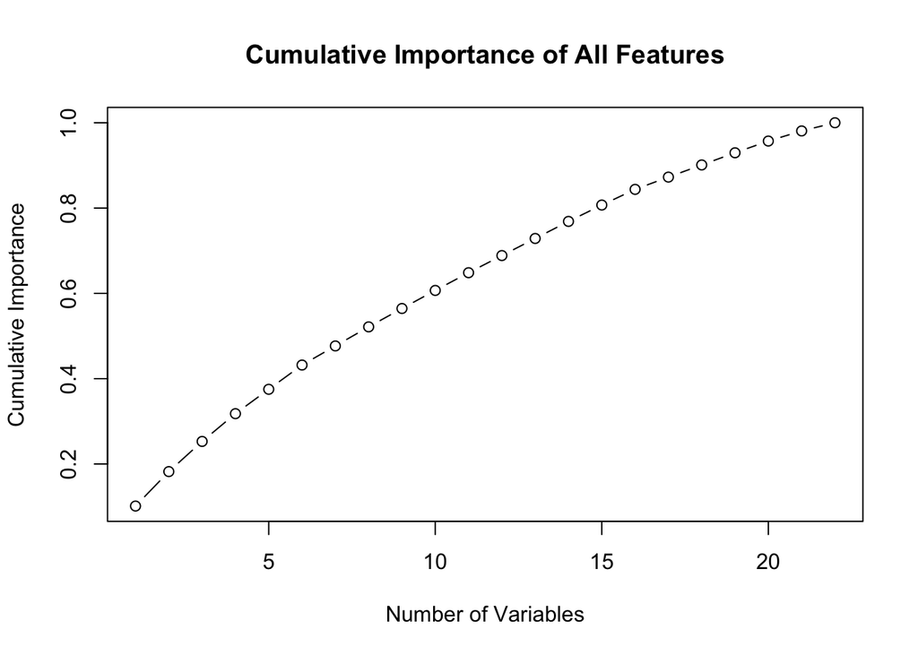

```r
# Calculate cumulative importance
cumulative_importance <- cumsum(importance_sorted$MeanDecreaseGini) / sum(importance_sorted$MeanDecreaseGini)

# Plot cumulative importance
plot(cumulative_importance, type = "b", main="Cumulative Importance of All Features", xlab = "Number of Variables", ylab = "Cumulative Importance")
```

```r
# Find the number of variables needed to achieve 90% cumulative importance
threshold_index <- which(cumulative_importance >= 0.9)[1]
print(paste("Number of selected features:", threshold_index))
```

```
## [1] "Number of selected features: 18"
```

```r
# Select out the data
selected_data <- data[c("Outstanding_Debt", "Interest_Rate", "Credit_Mix", "Credit_History_Age",
                      "Delay_from_due_date", "Changed_Credit_Limit", "Monthly_Balance",
                      "Amount_invested_monthly", "Credit_Utilization_Ratio", "Num_Credit_Card",
                      "Total_EMI_per_month", "Num_Credit_Inquiries", "Monthly_Inhand_Salary",
                      "Annual_Income", "Num_of_Delayed_Payment", "Age","Num_Bank_Accounts","Payment_of_Min_Amount",
                "Credit_Score")]
```

# 5 Classification methods used

#### LDA

LDA, as a simple and effective classification method, usually achieves high performance without the need for parameter adjustment. Therefore, we did not adjust the parameters of LDA but used the default values instead. We chose this because it’s suitable for multi-class classification

```r
# Split dataset
set.seed(5003)
lda.train_index <- createDataPartition(selected_data$Credit_Score, p = 0.8)[[1]]
lda.train_data <- selected_data[lda.train_index, ]
lda.test_data <- selected_data[-lda.train_index, ]

# Building LDA model
lda_model <- train(
  Credit_Score ~ .,
  data = lda.train_data,
  method = "lda",
  trControl = trainControl(method = "repeatedcv", repeats = 5),
)
```

```r
lda_pred <- predict(lda_model, newdata = lda.test_data)
```

```r
lda.confusionMatrix <-confusionMatrix(factor(lda_pred),factor(lda.test_data$Credit_Score))
lda.accuracy <- lda.confusionMatrix$overall["Accuracy"]
lda.metrics <- lda.confusionMatrix$byClass[, c("Precision", "Recall", "F1")]

print(lda.accuracy)
```

```
##  Accuracy
## 0.6424142
```

```r
print(lda.metrics)
```

```
##                 Precision    Recall        F1
## Class: Good     0.5232263 0.6350631 0.5737456
## Class: Poor     0.6445832 0.5519917 0.5947051
## Class: Standard 0.6895843 0.6941885 0.6918787
```

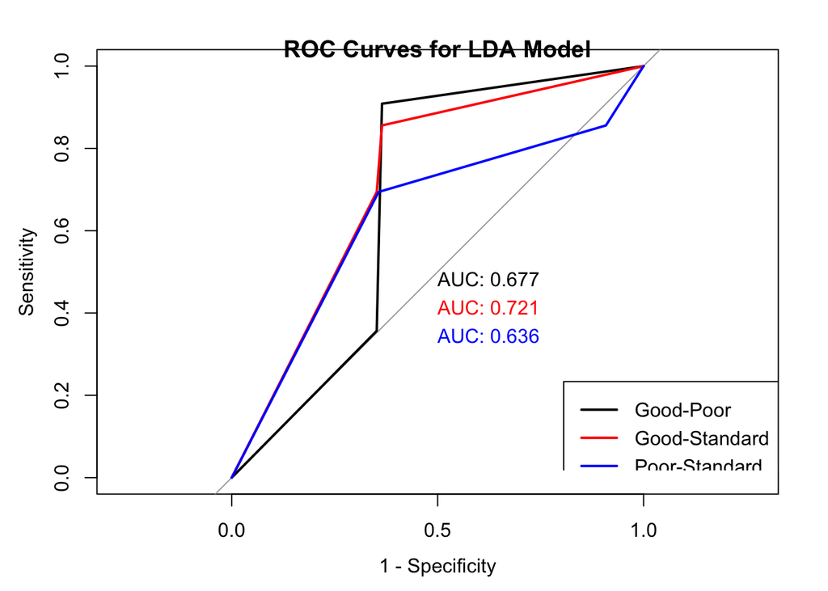

```r
lda.roc <- multiclass.roc(lda.test_data$Credit_Score, as.numeric(lda_pred), levels=base::levels(as.factor(lda.test_data$Credit_Score)))
plot.roc(lda.roc$rocs[[1]],
         print.auc=T,
         legacy.axes = T)
plot.roc(lda.roc$rocs[[2]],
         add=T, col = 'red',
         print.auc = T,
         legacy.axes = T,
         print.auc.adj = c(0,3))
plot.roc(lda.roc$rocs[[3]],add=T, col = 'blue',
         print.auc=T,
         legacy.axes = T,
         print.auc.adj = c(0,5))
title(main = "ROC Curves for LDA Model")
legend('bottomright',
       legend = c('Good-Poor',
                  'Good-Standard',
                  'Poor-Standard'),
       col=c('black','red','blue'),lwd=2)
```

#### kNN

kNN is one of the popular classification methods. The label that is most commonly expressed around a specific data point is utilised to assign a class label based on a majority vote. The method itself would choose the best k value in range 5, 7, 9 by itself. Therefore, there’s no need of additional parameter tuning method but just using repeated cross-validation to improve the performances to their best state. We chose this because it’s suitable for non-linear decision boundary classification

```r
set.seed(5003)
knn.train_index <- createDataPartition(selected_data$Credit_Score, p = 0.8, list = FALSE)
knn.train_data <- selected_data[knn.train_index, ]
knn.test_data <- selected_data[-knn.train_index, ]

# Define the train control for cross-validation
knn.ctrl <- trainControl(method = "repeatedcv", number = 10, repeats = 5)  # 10-fold cross-validation

# Train the KNN model using cross-validation
knn.model <- train(Credit_Score ~ ., data = knn.train_data, method = "knn", trControl = knn.ctrl)
```

```r
knn.predictions <- predict(knn.model, newdata = knn.test_data)
```

```r
# Calculate the confusion matrix
knn.conf_matrix <- confusionMatrix(knn.predictions, as.factor(knn.test_data$Credit_Score))

# Calculate metrics from the confusion matrix
knn.conf_matrix$overall["Accuracy"]
```

```
##  Accuracy
## 0.7572257
```

```r
knn.metrics <- knn.conf_matrix$byClass[,c("Precision", "Recall", "F1")]
knn.metrics
```

```
##                 Precision    Recall        F1
## Class: Good     0.6884707 0.6465638 0.6668595
## Class: Poor     0.7498780 0.7951371 0.7718447
## Class: Standard 0.7834492 0.7736506 0.7785190
```

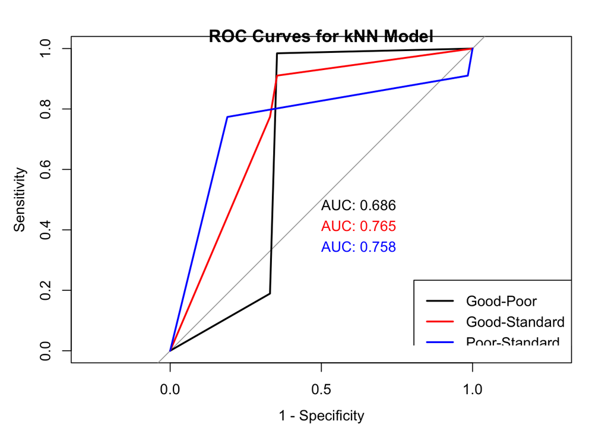

```r
knn.roc <- multiclass.roc(knn.test_data$Credit_Score, as.numeric(knn.predictions), levels=base::levels(as.factor(knn.test_data$Credit_Score)))
plot.roc(knn.roc$rocs[[1]],
         print.auc=T,
         legacy.axes = T)
plot.roc(knn.roc$rocs[[2]],
         add=T, col = 'red',
         print.auc = T,
         legacy.axes = T,
         print.auc.adj = c(0,3))
plot.roc(knn.roc$rocs[[3]],add=T, col = 'blue',
         print.auc=T,
         legacy.axes = T,
         print.auc.adj = c(0,5))
title(main = "ROC Curves for kNN Model")
legend('bottomright',
       legend = c('Good-Poor',
                  'Good-Standard',
                  'Poor-Standard'),
       col=c('black','red','blue'),lwd=2)
```

#### SVM

The goal of the SVM model is to find a hyperplane that divides the data points so that they are as far away as possible from the hyperplane. Its hyperparameters mainly include penalty parameters C, kernel, and sigma. C controls the tolerance of the model for misclassification, the kernel determines the way the model maps data, and sigma affects the range of influence of a single training sample on the model. We chose this because it’s suitable for non-linear decision boundary classification and multi-class data (one-to-one)

```r
# Split dataset
set.seed(5003)
svm.train_index <- createDataPartition(selected_data$Credit_Score, p = 0.8, list = FALSE)
svm.train_data <- selected_data[svm.train_index, ]
svm.test_data <- selected_data[-svm.train_index, ]

# Training SVM models
svm_model <- train(Credit_Score ~ ., data = svm.train_data,
                   method = "svmRadial",
                   trControl = trainControl(method = "cv", number = 5, search = "grid"),
                   preProcess = "scale",
                   tuneGrid = expand.grid(sigma = c(0.1,0.2), C = c(1,5)))
```

```r
# View model parameters

svm.predictions <- predict(svm_model, svm.test_data)
```

```r
svm.confusionMatrix <-confusionMatrix(factor(svm.predictions),factor(svm.test_data$Credit_Score))

svm.confusionMatrix$overall["Accuracy"]
```

```
##  Accuracy
## 0.7581758
```

```r
svm.metrics <- svm.confusionMatrix$byClass[, c("Precision", "Recall", "F1")]
print(svm.metrics)
```

```
##                 Precision    Recall        F1
## Class: Good     0.6708008 0.6978962 0.6840803
## Class: Poor     0.7597100 0.7589240 0.7593168
## Class: Standard 0.7882050 0.7779763 0.7830573
```

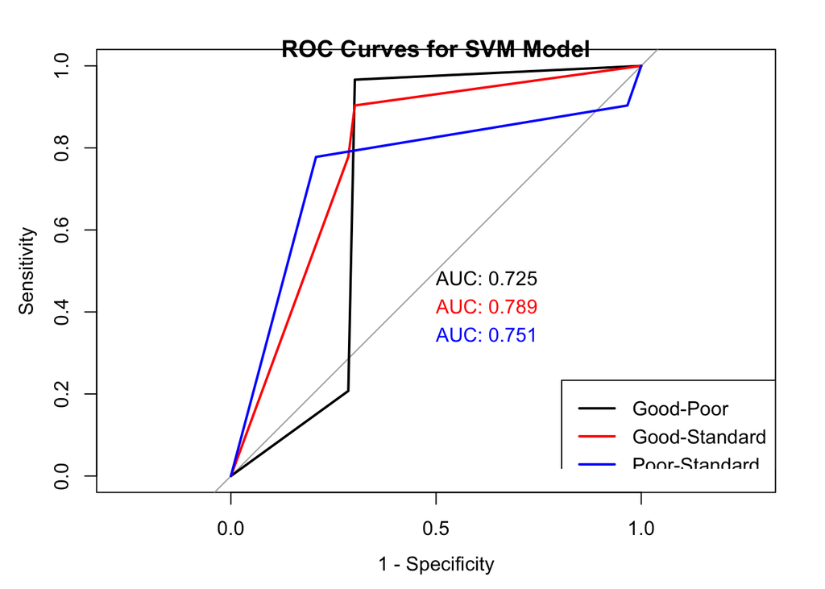

```r
svm.roc <- multiclass.roc(svm.test_data$Credit_Score, as.numeric(svm.predictions), levels=base::levels(as.factor(svm.test_data$Credit_Score)))
plot.roc(svm.roc$rocs[[1]],
         print.auc=T,
         legacy.axes = T)
plot.roc(svm.roc$rocs[[2]],
         add=T, col = 'red',
         print.auc = T,
         legacy.axes = T,
         print.auc.adj = c(0,3))
plot.roc(svm.roc$rocs[[3]],add=T, col = 'blue',
         print.auc=T,
         legacy.axes = T,
         print.auc.adj = c(0,5))
title(main = "ROC Curves for SVM Model")
legend('bottomright',
       legend = c('Good-Poor',
                  'Good-Standard',
                  'Poor-Standard'),
       col=c('black','red','blue'),lwd=2)
```

#### Random Forest

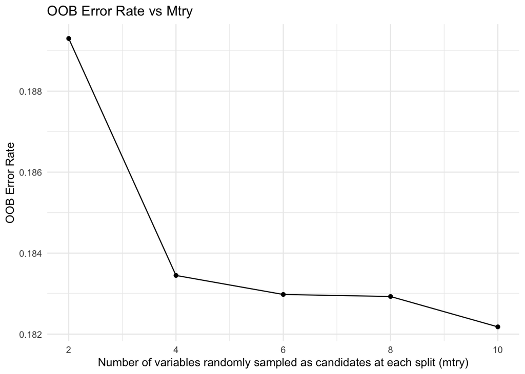

```r
library(parallel)

# Train the model
rf.model <- ranger(
    Credit_Score ~ .,
    data = selected_data,
    num.trees = 100,
    mtry = floor(sqrt(ncol(selected_data) - 1)),
    min.node.size = 10,
    num.threads = detectCores()
)

# Optimize the mtry parameter
mtry_values <- seq(2, 10, by = 2)
num_trees <- 100
oob_errors <- numeric(length(mtry_values))

for (i in seq_along(mtry_values)) {
  rf.model <- ranger(
    formula = Credit_Score ~ .,
    data = selected_data,
    num.trees = num_trees,
    mtry = mtry_values[i],
    min.node.size = 10,
    num.threads = detectCores()
  )
  oob_errors[i] <- rf.model$prediction.error
}

rf.results <- data.frame(mtry = mtry_values, OOB_Error = oob_errors)

# Plot OOB error rate curve
ggplot(rf.results, aes(x = mtry, y = OOB_Error)) +
  geom_line() +
  geom_point() +
  labs(title = "OOB Error Rate vs Mtry",
       x = "Number of variables randomly sampled as candidates at each split (mtry)",
       y = "OOB Error Rate") +
  theme_minimal()
```

```r
# Optimize the ntrees parameter
t.ntrees_values <- seq(100, 600, by = 100)
t.oob_errors <- numeric(length(t.ntrees_values))
t.mtry_values <- 4

for (i in seq_along(t.ntrees_values)) {
  rf.model <- ranger(
    formula = Credit_Score ~ .,
    data = selected_data,
    num.trees = t.ntrees_values[i],
    mtry = floor(sqrt(ncol(selected_data) - 1)),
    min.node.size = 10,
    num.threads = detectCores()
  )
  t.oob_errors[i] <- rf.model$prediction.error
}
```

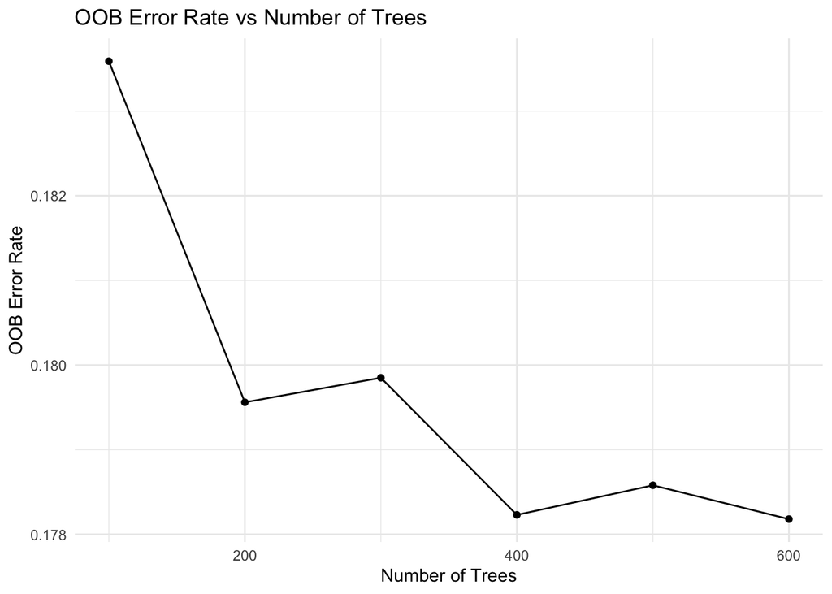

```r
t.results <- data.frame(ntrees = t.ntrees_values, OOB_Error = t.oob_errors)

# Plot OOB error rate curve
ggplot(t.results, aes(x = ntrees, y = OOB_Error)) +
  geom_line() +
  geom_point() +
  labs(title = "OOB Error Rate vs Number of Trees",
       x = "Number of Trees",
       y = "OOB Error Rate") +
  theme_minimal()
```

```r
# Divide training and testing sets
set.seed(5003)
rf.training_index <- sample(1:nrow(selected_data), 0.8 * nrow(selected_data))
rf.train_data <- selected_data[rf.training_index, ]
rf.test_data <- selected_data[-rf.training_index, ]

# Establishing a random forest model
rf.model <- randomForest(Credit_Score ~ ., data = rf.train_data, ntree = 500, mtry = 8)


rf.class_predictions <- predict(rf.model, rf.test_data)

rf.prob_predictions <- predict(rf.model, rf.test_data, type = "prob")
```

```r
# Calculate confusion matrix
rf.conf_matrix <- confusionMatrix(as.factor(rf.class_predictions), as.factor(rf.test_data$Credit_Score), mode = 'everything')

# Accuracy
rf.accuracy <- rf.conf_matrix$overall['Accuracy']
print(paste("Accuracy:", round(rf.accuracy, 3)))
```

```
## [1] "Accuracy: 0.817"
```

```r
rf.stats <- rf.conf_matrix$byClass[c("Precision", "Recall", "F1")]
rf.class_levels <- levels(rf.test_data$Credit_Score)


# Precision, Recall, F1
rf.precision <- rf.conf_matrix$byClass[, "Precision"]
rf.recall <- rf.conf_matrix$byClass[, "Recall"]
rf.f1_score <- rf.conf_matrix$byClass[, "F1"]


rf.class_levels <- gsub("Class: ", "", rownames(rf.conf_matrix$byClass))

# Print relevant statistical data
for (i in 1:length(rf.class_levels)) {
    cat("\n", rf.class_levels[i], "Metrics:\n")
    cat("Precision:", round(rf.precision[i], 3), "\n")
    cat("Recall:", round(rf.recall[i], 3), "\n")
    cat("F1 Score:", round(rf.f1_score[i], 3), "\n")
}
```

```
##
##  Good Metrics:
## Precision: 0.796
## Recall: 0.776
## F1 Score: 0.786
##
##  Poor Metrics:
## Precision: 0.797
## Recall: 0.842
## F1 Score: 0.818
##
##  Standard Metrics:
## Precision: 0.835
## Recall: 0.817
## F1 Score: 0.826
```

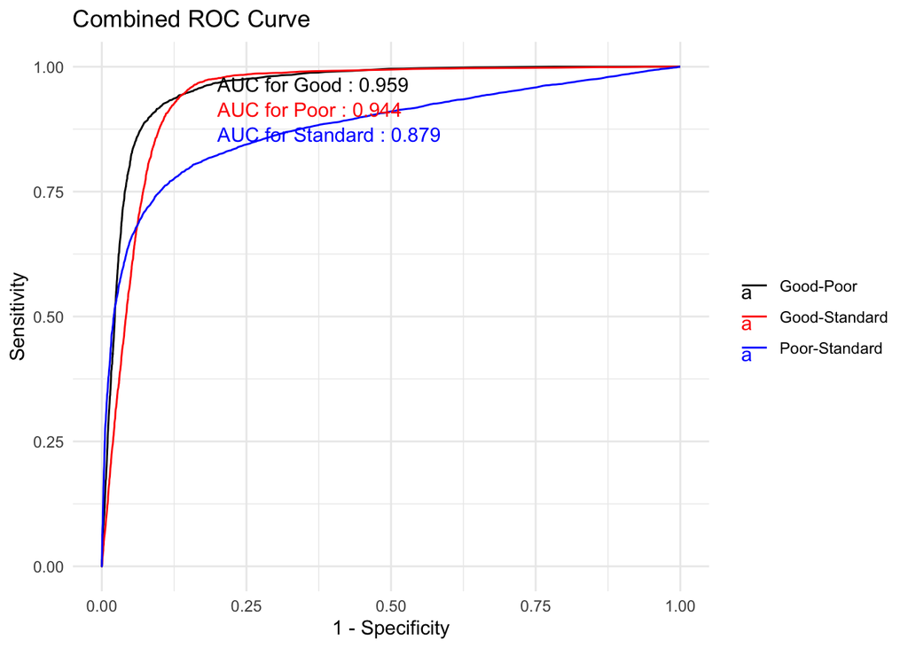

```r
# Prepare ROC data
rf.all_roc_data <- data.frame()
rf.label_data <- data.frame()

rf.class_levels <- levels(rf.test_data$Credit_Score)
rf.colors <- c("Good-Poor" = "black", "Good-Standard" = "red", "Poor-Standard" = "blue")
rf.plot_titles <- names(rf.colors)

for (i in 1:length(rf.class_levels)) {
    actuals <- ifelse(rf.test_data$Credit_Score == rf.class_levels[i], 1, 0)
    preds <- rf.prob_predictions[, rf.class_levels[i]]
    roc_obj <- roc(actuals, preds)
    auc_value <- auc(roc_obj)
    roc_data <- data.frame(
        specificity = 1 - roc_obj$specificities,
        sensitivity = roc_obj$sensitivities,
        class = rf.plot_titles[i]
    )
    rf.all_roc_data <- rbind(rf.all_roc_data, roc_data)

    rf.label_data <- rbind(rf.label_data, data.frame(
        specificity = 0.2,
        sensitivity = 1 - 0.05 * i,
        class = rf.plot_titles[i],
        label = paste("AUC for", rf.class_levels[i], ":", round(auc_value, 3))
    ))
}

# Plot ROC curve graph
ggplot(rf.all_roc_data, aes(x = specificity, y = sensitivity, color = class)) +
    geom_line() +
    scale_color_manual(values = rf.colors, name = NULL) +
    geom_text(data = rf.label_data, aes(label = label), hjust = 0, vjust = 0) +
    labs(title = "Combined ROC Curve", x = "1 - Specificity", y = "Sensitivity") +
    theme_minimal()
```

# 6 Classification performance evaluation

#### LDA

From the results, we can see that the performance of LDA is not particularly ideal. The accuracy is about 64%, which is not high. The F1-scores of the three classes are proportional to their prevalence in the entire dataset, with the largest ‘Standard’ class having an F1-score of 0.69. In terms of AUC-ROC, the Good-Poor and Good-Standard scenarios are roughly the same, while Poor-Standard is the lowest. The results may indicate that although LDA is suitable for handling multi-class problems, it performs poorly when dealing with imbalanced data.

#### kNN

The accuracy of KNN model is 75.72%, indicating that in most cases, the model can carry out correct classification, especially for multi-classification tasks, which is a relatively ideal level. The models have different performances when classifying different categories. It can be seen that the precision, recall and F1 score of Poor and Standard categories are high, indicating that the models perform well in these categories, while the performance of good category is poor, but still within a reasonable range. This may be due to uneven data distribution. Or good category data is caused by more noise and outliers. For AUC, the model has a higher AUC value for good-standard and poor-standard, indicating that the model can distinguish them better, while the ability to distinguish good-poor is poor.

#### SVM

The performance index of SVM model is similar to KNN model, and its accuracy reaches 75.81%, which is also an acceptable level, indicating that the model has a good classification ability. The same is true for precision, recall and F1 score, which exceeds 70% for both Poor and Standard categories, but only about 67% for Good categories, indicating that the model has better prediction accuracy for Poor and Standard. In contrast, although the AUC of the SVM model for the good-poor category is also the lowest among the three categories, the difference between the three AUC values of the SVM is smaller, all exceeding 0.7, which indicates that the SVM model can handle the situation of unclear category boundaries and performs well for mild nonlinear boundaries.

#### Random Forest

The results of the Random Forest are relatively good, with an accuracy of 81.7%. The F1-scores are above 0.81 for both Poor and Standard categories. While the performance on the Good category is lower than the other two, it still reaches 0.78. The AUC-ROC scores for Good-Poor and Good-Standard are quite good, though the score for Poor-Standard is slightly inferior. Although imbalanced data can affect the classification outcome of the Random Forest, the impact is minimal. The distinction between Poor and Standard is somewhat weaker, but it is still within an acceptable range.

#### Evaluation Conclusion

From the performance metrics, LDA performs the worst, with overall unsatisfactory results. kNN’s performance is a little slightly lower than SVM, which could be somehow same same with each other. Random Forest has the best results, showing higher outcomes across various performance metrics

# 7 Conclusion

The **kNN** model might underperform when class distributions overlap or in high-dimensional, noisy datasets, as irrelevant features reduce the impact of relevant ones (James et al., 2013). Improving kNN models involves reducing noise and dimensionality through feature engineering and fine-tuning the number of neighbors (K values) via cross-validation to prevent overfitting and enhance model robustness.  
The **LDA** model relies on linear decision boundaries limits its effectiveness in scenarios with complex, non-linear class separations, significantly impacting its performance (Izenman, 2008). To enhance LDA, integrate it with non-linear classifiers like SVM or Random Forest for capturing complex patterns, and ensure data normalization and standardization in preprocessing to reduce the impact of outliers and scale differences.  
In **SVM** model, the choice of kernel and its parameters greatly influences its performance, where incorrect selections can lead to overfitting or underfitting (Cortes & Vapnik, 1995). To further improve SVM, select the optimal kernel functions like linear, polynomial, or radial basis using cross-validation, and fine-tune the kernel parameters with Grid Search and cross-validation.  
**Random Forest’s** complexity can make it hard to explain, and using many deep trees can increase training time and memory usage. Optimal parameters like Number of Trees, Maximum Depth, and Minimum Samples for Splitting can be determined through cross-validation to minimize overfitting and model complexity (Breiman, 2001).  
In conclusion, the Random Forest model exhibits outstanding performance (high accuracy and detailed class differentiation) across all tested class pairs, showing high sensitivity and specificity. After comparing it with other models, it is evident that Random Forest is superior due to its ability to handle complex and non-linear relationships effectively.

# 8 References

Gupta, A. (2024). *Feature Selection Techniques in Machine Learning (Updated 2024)*. Analytics Vidhya. https://www.analyticsvidhya.com/blog/2020/10/feature-selection-techniques-in-machine-learning/

James, G., Witten, D., Hastie, T., & Tibshirani, R. (2013). “An Introduction to Statistical Learning.” Springer, New York.

Izenman, A. J. (2008). “Modern Multivariate Statistical Techniques: Regression, Classification, and Manifold Learning.” Springer, New York.

Cortes, C., & Vapnik, V. (1995). “Support-Vector Networks.” Machine Learning, 20(3), 273-297.

Breiman, L. (2001). “Random Forests.” Machine Learning, 45(1), 5-32.

# 9 Team Contribution

Overall, we all agree that our team members have equal contribution to the group work. Each member’s tasks are as below:

| Member | Assigned Tasks |
| --- | --- |
| Quynh Giang Le | -Research about cross-validation and data leakage problem -Perform kNN method -Integrate individual parts and finalize the report -Participate in presentation |
| Kairui Huang | -Research about imbalanced data problem -Perform LDA method -Write evaluation part -Participate in presentation |
| Rundong Shen | -Research about dimensionality reduction -Perform SVM method -Write evaluation part -Participate in presentation |
| Haoyu Fang | -Research about feature selection methods -Perform Random Forest method -Write conclusion part -Participate in presentation |
| Wanxin Bao | -Research about cross-validation and data leakage problem -Perform Random Forest method -Write conclusion part -Participate in presentation |